# Craft Beer Breweries

Pearly Paul and Kevin Albright

6/21/2021

## Introduction

### Loading the Datasets for Analysis

 We were provided with 2 data sets (`beers` and `breweries`). The `breweries` dataset contains the count of breweries from 50 states of the US and the `beer` data set contains the details of the beers (Alcohol by Volume Content and International Bitterness unit)  `Note : Beers dataset contains a list of 2410 US craft beers and Breweries dataset contains 558 US breweries.`  *Region Data : This is the data set we created for analysis group the 50 states in US into 4 regions North Central,North East , South and West*

```r
#Read in Core Data
Beers = read.csv("/Users/Kevin/Desktop/School/Doing Data Science/Project 1/Beers.csv", header = TRUE)
Breweries = read.csv("/Users/Kevin/Desktop/School/Doing Data Science/Project 1/Breweries.csv", header = TRUE)

#Bring in Region Data
RegionData = data.frame(State = state.abb, Region = state.region)
Breweries = left_join(Breweries,RegionData,by = "State")

#Handle NA and missing data by replacing with Regional Means
Breweries = sqldf('
      select
      "Brew_ID","Name","City","State",

      case when "State"  = "DC" then "South" else "Region" end as Region

      from
      Breweries
                 ')

Distilled_Data = merge(Beers,Breweries, by.x = "Brewery_id", by.y = "Brew_ID")
#Distilled_Data = left_join(Beers,Distilled_Data,by = "Beer_ID")

#Create table for IBU and ABV means by State and Region - excluding missing data
State_Means =
Distilled_Data[!is.na(Distilled_Data$ABV) & !is.na(Distilled_Data$IBU),] %>%
  group_by(State) %>%
  summarize(Mean_IBU_by_State = mean(IBU),
            Mean_ABV_by_State = mean(ABV))
Regional_Means =
  Distilled_Data[!is.na(Distilled_Data$ABV) & !is.na(Distilled_Data$IBU),] %>%
  group_by(Region) %>%
  summarize(Mean_IBU_by_Region = mean(IBU),
            Mean_ABV_by_Region = mean(ABV))

Distilled_Data = left_join(Distilled_Data,State_Means,by = "State")
Distilled_Data = left_join(Distilled_Data,Regional_Means,by = "Region")
```

## 3. Research Questions

 We are now going to analyze the research questions for EDA   ### 1. How many breweries are present in each state?  Here we used the breweries dataset to count the number of breweries per state in the US.  **Output : We were able to find Colorado and California to have the highest number of Craft breweries in US.**

```r
kable(count(Breweries,State))
```

| State | n |
| --- | --- |
| AK | 7 |
| AL | 3 |
| AR | 2 |
| AZ | 11 |
| CA | 39 |
| CO | 47 |
| CT | 8 |
| DC | 1 |
| DE | 2 |
| FL | 15 |
| GA | 7 |
| HI | 4 |
| IA | 5 |
| ID | 5 |
| IL | 18 |
| IN | 22 |
| KS | 3 |
| KY | 4 |
| LA | 5 |
| MA | 23 |
| MD | 7 |
| ME | 9 |
| MI | 32 |
| MN | 12 |
| MO | 9 |
| MS | 2 |
| MT | 9 |
| NC | 19 |
| ND | 1 |
| NE | 5 |
| NH | 3 |
| NJ | 3 |
| NM | 4 |
| NV | 2 |
| NY | 16 |
| OH | 15 |
| OK | 6 |
| OR | 29 |
| PA | 25 |
| RI | 5 |
| SC | 4 |
| SD | 1 |
| TN | 3 |
| TX | 28 |
| UT | 4 |
| VA | 16 |
| VT | 10 |
| WA | 23 |
| WI | 20 |
| WV | 1 |
| WY | 4 |

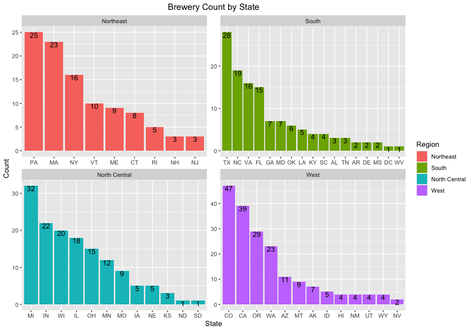

```r
#Brewery Count by State
Breweries %>%
  group_by(State,Region) %>%
  summarize(Count = n()) %>%
  ggplot(aes(x = reorder(State,-Count), y = Count,fill=Region)) +
  geom_bar(stat = "identity") +
  geom_text(aes(label=Count),vjust=1) +
  ggtitle("Brewery Count by State",) + xlab("State") + ylab("Count") +
  facet_wrap(~Region, scales="free") +
  theme(plot.title=element_text(hjust=.5))
```

```r
kable(head(Distilled_Data))
```

| Brewery_id | Name.x | Beer_ID | ABV | IBU | Style | Ounces | Name.y | City | State | Region | Mean_IBU_by_State | Mean_ABV_by_State | Mean_IBU_by_Region | Mean_ABV_by_Region |
| --- | --- | --- | --- | --- | --- | --- | --- | --- | --- | --- | --- | --- | --- | --- |
| 1 | Get Together | 2692 | 0.045 | 50 | American IPA | 16 | NorthGate Brewing | Minneapolis | MN | North Central | 49.95652 | 0.0604348 | 39.19035 | 0.059126 |
| 1 | Maggie’s Leap | 2691 | 0.049 | 26 | Milk / Sweet Stout | 16 | NorthGate Brewing | Minneapolis | MN | North Central | 49.95652 | 0.0604348 | 39.19035 | 0.059126 |
| 1 | Wall’s End | 2690 | 0.048 | 19 | English Brown Ale | 16 | NorthGate Brewing | Minneapolis | MN | North Central | 49.95652 | 0.0604348 | 39.19035 | 0.059126 |
| 1 | Pumpion | 2689 | 0.060 | 38 | Pumpkin Ale | 16 | NorthGate Brewing | Minneapolis | MN | North Central | 49.95652 | 0.0604348 | 39.19035 | 0.059126 |
| 1 | Stronghold | 2688 | 0.060 | 25 | American Porter | 16 | NorthGate Brewing | Minneapolis | MN | North Central | 49.95652 | 0.0604348 | 39.19035 | 0.059126 |
| 1 | Parapet ESB | 2687 | 0.056 | 47 | Extra Special / Strong Bitter (ESB) | 16 | NorthGate Brewing | Minneapolis | MN | North Central | 49.95652 | 0.0604348 | 39.19035 | 0.059126 |

```r
kable(tail(Distilled_Data))
```

|  | Brewery_id | Name.x | Beer_ID | ABV | IBU | Style | Ounces | Name.y | City | State | Region | Mean_IBU_by_State | Mean_ABV_by_State | Mean_IBU_by_Region | Mean_ABV_by_Region |
| --- | --- | --- | --- | --- | --- | --- | --- | --- | --- | --- | --- | --- | --- | --- | --- |
| 2405 | 556 | Pilsner Ukiah | 98 | 0.055 | NA | German Pilsener | 12 | Ukiah Brewing Company | Ukiah | CA | West | 46.28148 | 0.0628889 | 45.52468 | 0.0607569 |
| 2406 | 557 | Heinnieweisse Weissebier | 52 | 0.049 | NA | Hefeweizen | 12 | Butternuts Beer and Ale | Garrattsville | NY | Northeast | 46.00000 | 0.0604565 | 41.57843 | 0.0585980 |
| 2407 | 557 | Snapperhead IPA | 51 | 0.068 | NA | American IPA | 12 | Butternuts Beer and Ale | Garrattsville | NY | Northeast | 46.00000 | 0.0604565 | 41.57843 | 0.0585980 |
| 2408 | 557 | Moo Thunder Stout | 50 | 0.049 | NA | Milk / Sweet Stout | 12 | Butternuts Beer and Ale | Garrattsville | NY | Northeast | 46.00000 | 0.0604565 | 41.57843 | 0.0585980 |
| 2409 | 557 | Porkslap Pale Ale | 49 | 0.043 | NA | American Pale Ale (APA) | 12 | Butternuts Beer and Ale | Garrattsville | NY | Northeast | 46.00000 | 0.0604565 | 41.57843 | 0.0585980 |
| 2410 | 558 | Urban Wilderness Pale Ale | 30 | 0.049 | NA | English Pale Ale | 12 | Sleeping Lady Brewing Company | Anchorage | AK | West | 40.88235 | 0.0561765 | 45.52468 | 0.0607569 |

```r
write.csv(Distilled_Data,"/Users/Kevin/Desktop/School/Doing Data Science/Project 1/Distilled_Data.csv")
write.csv(RegionData,"/Users/Kevin/Desktop/School/Doing Data Science/Project 1/Region_Data.csv")
```

## 3.Address the missing values in each column.

**2.Breweries Data set :** + No missing data

```r
Distilled_Data2 = Distilled_Data

Distilled_Data2 =
Distilled_Data2 %>%
  mutate(ABV = coalesce(Distilled_Data2$ABV,Distilled_Data2$Mean_ABV_by_State),
         IBU = coalesce(coalesce(Distilled_Data2$IBU,Distilled_Data2$Mean_IBU_by_State),Distilled_Data2$Mean_IBU_by_Region))
```

## 4.Compute the median alcohol content and international bitterness unit for each state. Plot a bar chart to compare.

 *Calculation of the median Alcohol content of each state grouped by region*   ### +4a. Median Alcohol Content - After plotting we discovered that the state with the highest median ABV was Kentucky with an ABV of .064 hailing from the Southern Region. The median bitterness was highest in West Virginia again from the Southern Region.

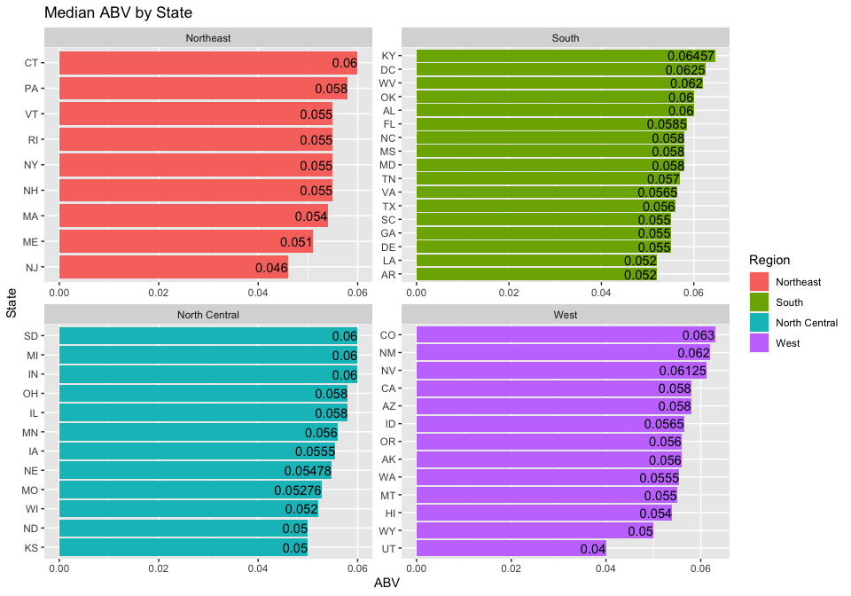

```r
#Median ABV
Distilled_Data2 %>%
  group_by(State,Region) %>%
  summarize(
    Median_Alcohol_Content = round(median(ABV,na.rm=TRUE),digits=5),
    Median_Bitterness = median(IBU,na.rm=TRUE)
  ) %>%
  ggplot(aes(reorder(x = State,Median_Alcohol_Content), y = Median_Alcohol_Content,fill=Region)) + geom_bar(stat="identity") +
  xlab("State") + ylab("ABV") + ggtitle("Median ABV by State") + facet_wrap(~Region, scales="free") +
  geom_text(aes(label=round(Median_Alcohol_Content,digits=6)),hjust=1) +
  coord_flip()
```

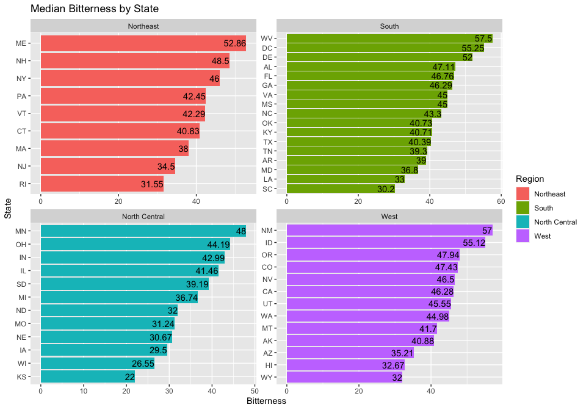

```r
#Median Bitterness
Distilled_Data2 %>%
  group_by(State,Region) %>%
  summarize(
    Median_Bitterness = median(IBU,na.rm=TRUE),
    Median_Alcohol_Content = median(ABV,na.rm=TRUE)
  ) %>%
  ggplot(aes(reorder(x = State,Median_Bitterness), y = Median_Bitterness,fill=Region)) + geom_bar(stat="identity") +
  xlab("State") + ylab("Bitterness") + ggtitle("Median Bitterness by State") + coord_flip() +
  geom_text(aes(label=round(Median_Bitterness,digits=2)),hjust=1) +
  facet_wrap(~Region, scales="free")
```

## 5.Which state has the maximum alcoholic (ABV) beer? Which state has the most bitter (IBU) beer?  ### 5a. Most Alcoholic Beer in US  ### Observation : Upon analysis the beer with maximum alcohol is made in the `Lee Hill Series Vol.5` made in Colorado West

### 5b. Most Bitter Beer in US

### Observation : Upon analysis the beer with maximum bitter content is `Bitter Bitch Imperial IPA` made in Oregano in West Region

```r
Top_ABV = Distilled_Data2[order(-Distilled_Data2$ABV),]
kable(head(Top_ABV,1))
```

|  | Brewery_id | Name.x | Beer_ID | ABV | IBU | Style | Ounces | Name.y | City | State | Region | Mean_IBU_by_State | Mean_ABV_by_State | Mean_IBU_by_Region | Mean_ABV_by_Region |
| --- | --- | --- | --- | --- | --- | --- | --- | --- | --- | --- | --- | --- | --- | --- | --- |
| 375 | 52 | Lee Hill Series Vol. 5 - Belgian Style Quadrupel Ale | 2565 | 0.128 | 47.43151 | Quadrupel (Quad) | 19.2 | Upslope Brewing Company | Boulder | CO | West | 47.43151 | 0.0648356 | 45.52468 | 0.0607569 |

```r
Most_Bitter = Distilled_Data2[order(-Distilled_Data2$IBU),]
kable(head(Most_Bitter,1))
```

|  | Brewery_id | Name.x | Beer_ID | ABV | IBU | Style | Ounces | Name.y | City | State | Region | Mean_IBU_by_State | Mean_ABV_by_State | Mean_IBU_by_Region | Mean_ABV_by_Region |
| --- | --- | --- | --- | --- | --- | --- | --- | --- | --- | --- | --- | --- | --- | --- | --- |
| 1857 | 375 | Bitter Bitch Imperial IPA | 980 | 0.082 | 138 | American Double / Imperial IPA | 12 | Astoria Brewing Company | Astoria | OR | West | 47.94253 | 0.0567011 | 45.52468 | 0.0607569 |

## 6. Comment on the summary statistics and distribution of the ABV variable.

### Observation : The chart shows a right tailed distribution with the majority of alcohol content hovering between .05 and .06

```r
summary(Distilled_Data2$ABV)
```

```
##    Min. 1st Qu.  Median    Mean 3rd Qu.    Max.
## 0.00100 0.05000 0.05700 0.05979 0.06700 0.12800
```

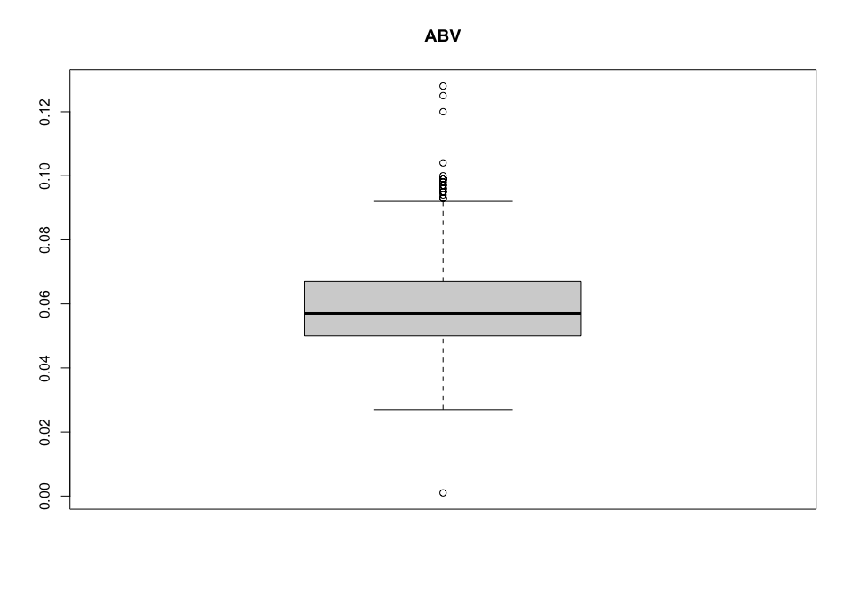

```r
boxplot(Distilled_Data2$ABV,main="ABV")
```

### 7. Is there an apparent relationship between the bitterness of the beer and its alcoholic content? Draw a scatter plot.  
## Observation : We observed a positive linear correlation between ABV and IBU. Overall, as the bitterness increased so did the alcohol content.

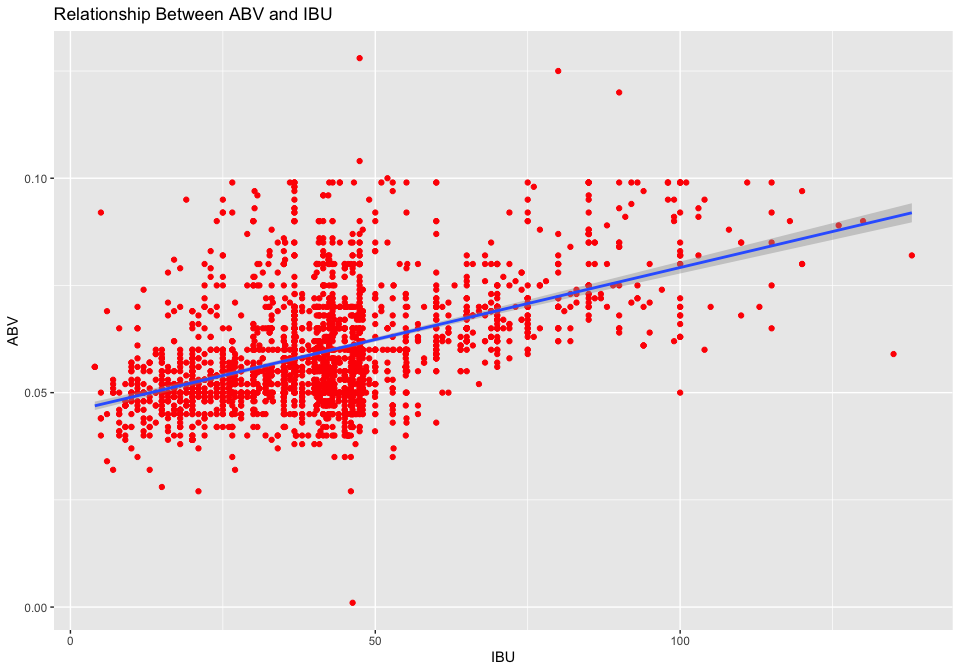

```r
Distilled_Data2 %>% ggplot(aes(x=IBU, y=ABV)) + geom_point(color="red") + geom_smooth(method="lm") +
  ggtitle("Relationship Between ABV and IBU")
```

### 8. Use KNN to differentiate the beer from Ale or IPA Beer

## Observation : First we had to filter the data set to only ALE and IPA beers then plot the relationship by region.

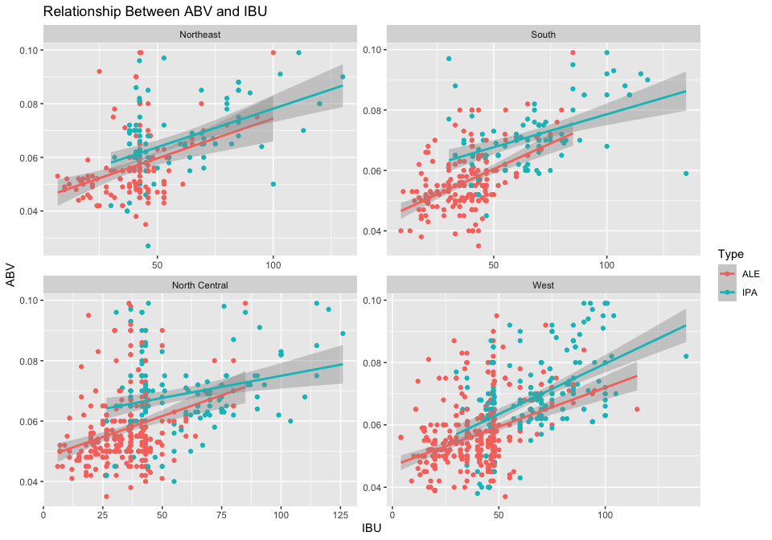

```r
#Relationship Between IBU and ABV by Type
IPA_ALE = sqldf('
  select
  "Name","Style" as Style,"ABV","IBU","State","Region","City",
  case when "Style" like "%ALE%" then "ALE"
       when "Style" like "%IPA%" then "IPA" end as Type
 from
  Distilled_Data2
 where
  "Style" like "%ALE%" OR "Style" like "%IPA%"
 ')

IPA_ALE %>% ggplot(aes(x=IBU, y=ABV,color=Type)) + geom_point() + geom_smooth(method="lm") +
  ggtitle("Relationship Between ABV and IBU") +
  facet_wrap(~Region,scales="free")
```

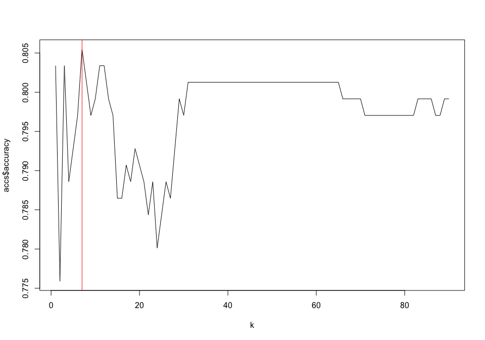

```r
splitPerc = .70
trainBeer = sample(1:dim(IPA_ALE)[1],round(splitPerc * dim(IPA_ALE)[1]))
train = IPA_ALE[trainBeer,]
test = IPA_ALE[-trainBeer,]

accs = data.frame(accuracy = numeric(90), k = numeric(90))

for(i in 1:90)
{
  classifications = knn(train[,c(3,4)],test[,c(3,4)],train$Type, prob = TRUE, k = i)
  table(test$Type,classifications)
  CM = confusionMatrix(table(test$Type,classifications))
  accs$accuracy[i] = CM$overall[1]
  accs$k[i] = i
}
plot(accs$k,accs$accuracy, type = "l", xlab = "k")
abline(v=accs$k[which.max(accs$accuracy)], col="red")
```

```r
accs$k[which.max(accs$accuracy)]
```

```
## [1] 7
```

```r
splitPerc = .70
trainIndices = sample(1:dim(IPA_ALE)[1],round(splitPerc * dim(IPA_ALE)[1]))
train = IPA_ALE[trainIndices,]
test = IPA_ALE[-trainIndices,]

classification = knn(IPA_ALE[,c(3,4)],IPA_ALE[,c(3,4)],IPA_ALE$Type,prob = TRUE, k = 5)
table(classification,IPA_ALE$Type)
```

```
##
## classification ALE IPA
##            ALE 922 145
##            IPA  98 413
```

```r
confusionMatrix(table(classification,IPA_ALE$Type))
```

```
## Confusion Matrix and Statistics
##
##
## classification ALE IPA
##            ALE 922 145
##            IPA  98 413
##
##                Accuracy : 0.846
##                  95% CI : (0.8272, 0.8635)
##     No Information Rate : 0.6464
##     P-Value [Acc > NIR] : < 2.2e-16
##
##                   Kappa : 0.6566
##
##  Mcnemar's Test P-Value : 0.003168
##
##             Sensitivity : 0.9039
##             Specificity : 0.7401
##          Pos Pred Value : 0.8641
##          Neg Pred Value : 0.8082
##              Prevalence : 0.6464
##          Detection Rate : 0.5843
##    Detection Prevalence : 0.6762
##       Balanced Accuracy : 0.8220
##
##        'Positive' Class : ALE
##
```

#Additional Insight on Craft beer’s and breweries ## Observation : We found that the southern and western regions consume alcohol with higher bitterness and the northeast and northern regions prefer a less alcoholic content in their beer. The geographipal map of US shows the state groupings by regions.

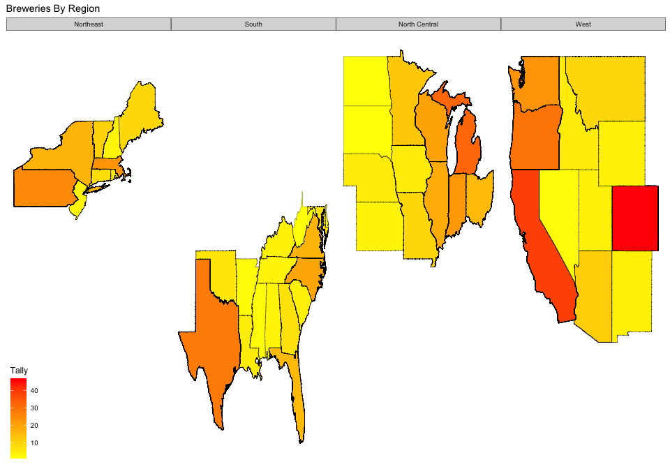

```r
map_data = map_data('state')
map_data = map_data %>% mutate(State = state2abbr(map_data$region))

Final_Breweries = left_join(Breweries,map_data, by = 'State')
Count_Breweries = Breweries %>%
  group_by(State) %>%
  summarize(Tally = n())

New_Breweries = left_join(Final_Breweries,Count_Breweries,by = 'State')
p0 <- ggplot(data = New_Breweries,
             mapping = aes(x = long, y = lat,
                           group = group,fill=Tally))
p1 <- p0 + geom_polygon(color = "black", size = 0.1) +
  theme_map() +
  scale_fill_gradient2(low = "green",
                       mid = "yellow",
                       high = "red") +
  ggtitle("Breweries By Region") +
  facet_grid(~Region, scales="free")
p1
```